# Assignment 2 (due on 10/27)

# 学生：王莺 (12131079)，Github: MascotWy

# 得分：44/50

## 1. Significant earthquakes since 2150 B.C.

### 1.1

```python
import pandas as pd
import matplotlib.pyplot as plt
earthquakes=pd.read_csv('./earthquakes-2021-10-22_10-51-46_+0800.tsv',sep='\t')
###1.1 top ten countries along with the total number of deaths
earthquakes.groupby('Country').sum()['Total Injuries'].head(10)
```

```
Country
AFGHANISTAN             8185.0
ALBANIA                 2247.0
ALGERIA                27126.0
ANTARCTICA                 0.0
ANTIGUA AND BARBUDA        4.0
ARGENTINA                611.0
ARMENIA                    0.0
ATLANTIC OCEAN             0.0
AUSTRALIA                103.0
AUSTRIA                    0.0
Name: Total Injuries, dtype: float64
```

### 本题是要计算地震引发的death死亡数量，而不是injuries受伤数量。另外，需要打印的是death数量排名top10的国家信息出来，该代码中应该补充排序的算法，如`sort_values()`。

### 1.2

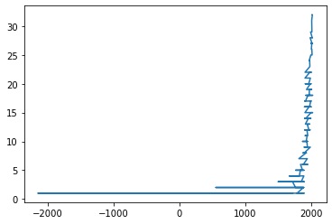

```python
###1.2 time series of total number of earthquakes with magnitude larger than 6.0
count=earthquakes[earthquakes['Mag']>6]['Year'].value_counts()
count.plot()
plt.show()
```

### 本题是要计算地震次数的时间序列变化，代码中的count数据集没有在时间上进行排序，所以出的图片很奇怪，不合常理。应当先使用`sort_index()` 对count沿时间进行排序后再画图，如下所示。

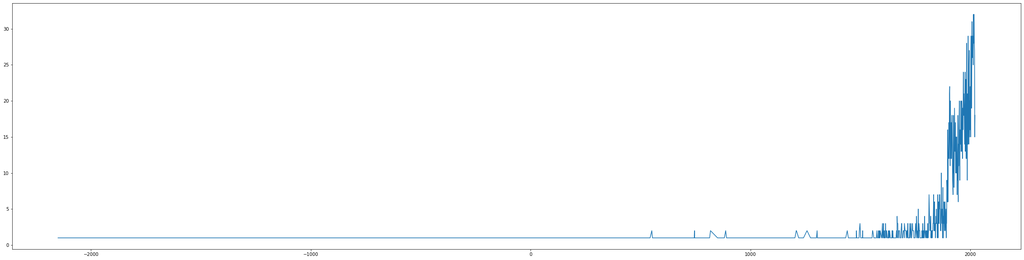

```python
count.sort_index().plot(figsize=(40,10))
```

### 1.3

```python
###1.3
def CountEq_LargestEq(string):
    CountEq2=len(earthquakes[earthquakes['Countries']==string]['Year'].value_counts())
    LargestEq_index=earthquakes[earthquakes['Countries']==string]['magnitude'].idxmax()
    LargestEq2 = str(int(earthquakes.loc[LargestEq_index-1]['Yr']))+'-'+str(int(earthquakes.loc[LargestEq_index-1]['Month']))+'-'+str(int(earthquakes.loc[LargestEq_index-1]['Day']))
    return CountEq2,LargestEq2

Countries=[]
CountEqList=[]
LargestEqList=[]
earthquakes['Yr']=earthquakes['Year'].fillna(value=0)
earthquakes['Month']=earthquakes['Mo'].fillna(value=0)
earthquakes['Day']=earthquakes['Dy'].fillna(value=0)
earthquakes['Countries']=earthquakes['Country'].fillna(value='Others')
earthquakes['magnitude']=earthquakes['Mag'].fillna(value=0)

for i in earthquakes['Countries'].drop_duplicates().dropna().values:
    Countries.append(i)
    CountEq,LargestEq=CountEq_LargestEq(i)
    CountEqList.append(CountEq)
    LargestEqList.append(LargestEq)
diction=dict(zip(Countries,CountEqList))
print(sorted(diction.items(),key=lambda x:x[1],reverse=True))
```

[output not shown]

## 第一题代码运行正常，可以输出结果，报告中也展示了输出内容，也针对问题给出文字分析，但是：

````
1、第一小题参量选择有误；
2、第二小题在作图前缺少对数据集的整理，作图效果有问题；
3、第三小题没有给出``` the date of the largest earthquake ever happened in this country```
````

## 得分：22/25

# ----------------------------------------------------

## 2. Wind speed in Shenzhen during the past 10 years

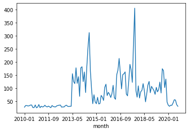

```python
import pandas as pd
import matplotlib.pyplot as plt

wind=pd.read_csv('./2281305.csv')
wind['month']=wind['DATE'].astype("str").str[0:7]
wind['speed']=wind['WND'].str[8:12].astype("float")
wind.groupby(['month'])['speed'].mean().plot()
plt.show()
#print(wind['month'])
#print(wind['speed'])
```

### 结果有问题，深圳的月均风速不可能达到几百米每秒，与常识不服。这其中的问题很可能是没有对数据进行清洗造成的。“9999”的不是风速值，只是无效值的另一个表示方法，需要替换成 Nan。

### 从下面的展示来看，`wind_df['wind_speed']` 里面有638条数据是9999，并且没有得到处理。

```python
wind['speed'][wind['speed']==9999]
```

```
29394     9999.0
29398     9999.0
29582     9999.0
29606     9999.0
29726     9999.0
           ...
104321    9999.0
104463    9999.0
104471    9999.0
104513    9999.0
105135    9999.0
Name: speed, Length: 638, dtype: float64
```

### 第二题代码运行正常，可以输出结果。报告中也做了相应展示。但是：

```
1、需要文字说明本题中获取风速信息的过程和数据清洗思路；
2、本题因为缺少对数据的清洗环节，导致数据结果超出常识，建议详细查阅数据介绍文档关于一些特殊值如“9999”的说明；
3、作图一定要表示出横纵轴的单位，而不能单纯显示数字。
```

## 得分：7/10

## 3. Explore a data set

```
365
75.88246575342465
85.0
53.5
```

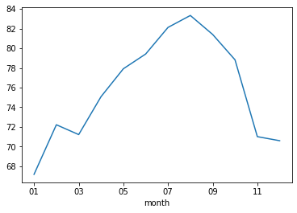

```python
import pandas as pd
import math
import matplotlib.pyplot as plt

temp=pd.read_csv('./99405099999.csv')
###3.1clean missing values
temp['temperature']=temp['TEMP'].dropna()
#print(temp['temperature'])

###3.2Plot the time series
#temp['temperature'].plot()
#plt.show()

###3.3 5 simple statistical checks
print(temp['temperature'].count())
print(temp['temperature'].mean())
print(temp['temperature'].max())
print(temp['temperature'].min())
temp['dy']=pd.to_datetime(temp['DATE'])
temp['month']=temp['dy'].astype("str").str[5:7]
temp.groupby(['month'])['temperature'].mean().plot()
plt.show()
```

## 第三题代码输出结果正确，也在报告中展现了输出结果。

## 得分 15/15

# ----------------------------------------------------